# Organización y Visualización: Variables cualitativas

Evelyn Gutierrez[^1]

Abril, 2021

Para la sesión, necesitamos instalar los siguientes paquetes:

- janitor
- summarytools
- tidyverse

Para instalarlos, utilizamos los siguientes comandos en la consola una sola vez.

```r
install.packages("janitor")
install.packages("summarytools")
install.packages("tidyverse")
```

–

Luego, esperamos a que complete la instalación y verificamos:

```r
library(janitor)
library(summarytools)
library(ggplot2)
```

# 1 Lectura de datos.

Con el siguiente código, leemos los datos directamente desde un enlace:

```r
# Cargar los datos sobre Cancer de mama:
url<-"https://archive.ics.uci.edu/ml/machine-learning-databases/breast-cancer/breast-cancer.data"
datos <- read.table(url, sep=",",stringsAsFactors=TRUE)
names(datos) <- c("clase","edad","menopausia","tamanio",
                       "inv_nodes","node_caps","deg_malig",
                       "breast","breast_quad","irradiat")
## Mas informacion en: https://archive.ics.uci.edu/ml/datasets/Breast+Cancer
```

# 2 Exploración inicial.

Exploramos el dataset observando los primeros 6 registros. Para ello, usamos el comando `head`:

```r
head(datos) # primeros 6
```

[output not shown]

Luego, realizamos una exploración del tipo de columnas que tiene este dataset.

```r
str(datos)
```

```
## 'data.frame':    286 obs. of  10 variables:
##  $ clase      : Factor w/ 2 levels "no-recurrence-events",..: 1 1 1 1 1 1 1 1 1 1 ...
##  $ edad       : Factor w/ 6 levels "20-29","30-39",..: 2 3 3 5 3 5 4 5 3 3 ...
##  $ menopausia : Factor w/ 3 levels "ge40","lt40",..: 3 3 3 1 3 1 3 1 3 3 ...
##  $ tamanio    : Factor w/ 11 levels "0-4","10-14",..: 6 4 4 3 1 3 5 4 11 4 ...
##  $ inv_nodes  : Factor w/ 7 levels "0-2","12-14",..: 1 1 1 1 1 1 1 1 1 1 ...
##  $ node_caps  : Factor w/ 3 levels "?","no","yes": 2 2 2 2 2 2 2 2 2 2 ...
##  $ deg_malig  : int  3 2 2 2 2 2 2 1 2 2 ...
##  $ breast     : Factor w/ 2 levels "left","right": 1 2 1 2 2 1 1 1 1 2 ...
##  $ breast_quad: Factor w/ 6 levels "?","central",..: 3 6 3 4 5 3 3 3 3 4 ...
##  $ irradiat   : Factor w/ 2 levels "no","yes": 1 1 1 1 1 1 1 1 1 1 ...
```

Observamos que en este set de datos todas las variables excepto `deg_malig` son de tipo factor (observe ‘Factor’ al lado de cada variable).

## 2.1 Tablas de Frecuencias.

Las tablas de frecuencias se pueden construir de diferentes maneras en R.

- Aquí veremos 3 formas.

[output not shown]

**Interpretación**: - Tenemos 201 casos de eventos no recurrentes de cáncer, y - 85 observaciones con eventos recurrentes de cáncer,

#### 2.1.0.1 Proporciones.

```r
# prop.table convierte la tabla a proporciones
proptable <- prop.table(table(datos$clase))
# round redondea a los digitos indicados en el segundo argumento.
round(proptable, 3)
```

```
##
## no-recurrence-events    recurrence-events
##                0.703                0.297
```

–

**Interpretación**: - El 70.3% de las observaciones son eventos no recurrentes de cáncer, y - 29.7% de las observaciones son eventos recurrentes de cáncer,

–

```r
# El comando as.data.frame convierte esta tabla a un data frame para mejorar la visualización
as.data.frame(proptable)
```

```
##                   Var1      Freq
## 1 no-recurrence-events 0.7027972
## 2    recurrence-events 0.2972028
```

### 2.1.1 Utilizando `janitor`

Ahora, exploramos la variable `age` con tablas de frecuencias. Esta vez utilizaremos el paquete janitor para una mejor visualización.

Utilizamos el comando `tabyl` para crear la tabla de frecuencias y observamos los resultados e interpretamos.

```r
library(janitor)
janitor::tabyl(datos$edad)
```

```
##  datos$edad  n     percent
##       20-29  1 0.003496503
##       30-39 36 0.125874126
##       40-49 90 0.314685315
##       50-59 96 0.335664336
##       60-69 57 0.199300699
##       70-79  6 0.020979021
```

### 2.1.2 Utilizando `summarytools`

Otra opción es usar el paquete `summarytools`. Si ya realizó la instalación, utilice el siguiente código:

```r
library(summarytools)
summarytools::freq(datos$menopausia,
                   order = "freq")
```

```
## Frequencies
## datos$menopausia
## Type: Factor
##
##                 Freq   % Valid   % Valid Cum.   % Total   % Total Cum.
## ------------- ------ --------- -------------- --------- --------------
##       premeno    150     52.45          52.45     52.45          52.45
##          ge40    129     45.10          97.55     45.10          97.55
##          lt40      7      2.45         100.00      2.45         100.00
##          <NA>      0                               0.00         100.00
##         Total    286    100.00         100.00    100.00         100.00
```

–

## 2.2 Gráfico circular

Para crear un gráfico circular, utilizamos el comando `pie`. Por ejemplo, lo utilizaremos para observar la clasificación de los casos de cancer.

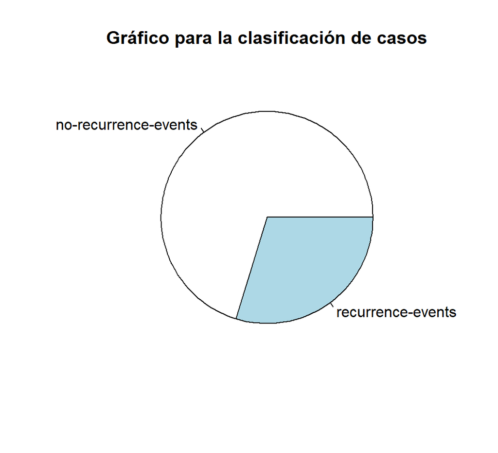

```r
pie(table(datos$clase),
    main="Gráfico para la clasificación de casos")
```

Note que despues de *main* vemos un texto. Este texto es el título principal (main) del gráfico. Podemos modificar el título, cambiando el texto dentro de las comillas.

Alternativamente, podemos utilizar la librería ggplot para crear un gráfico de pie con mejor apariencia.

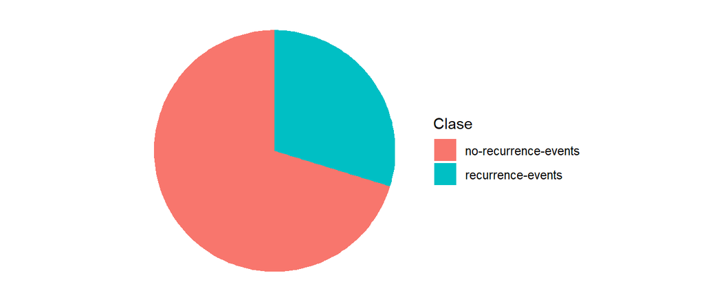

```r
tabla_clase <- data.frame(table(datos$clase))
names(tabla_clase) <- c("Clase","Frecuencia")

library(ggplot2)
ggplot(tabla_clase,
       aes(x="", y=Frecuencia, fill=Clase)) +
  geom_bar(stat="identity", width=1) +
  coord_polar("y", start=0) + theme_void()
```

## 2.3 Gráfico de barras.

Creamos el gráfico de barras para la variable menopausia.

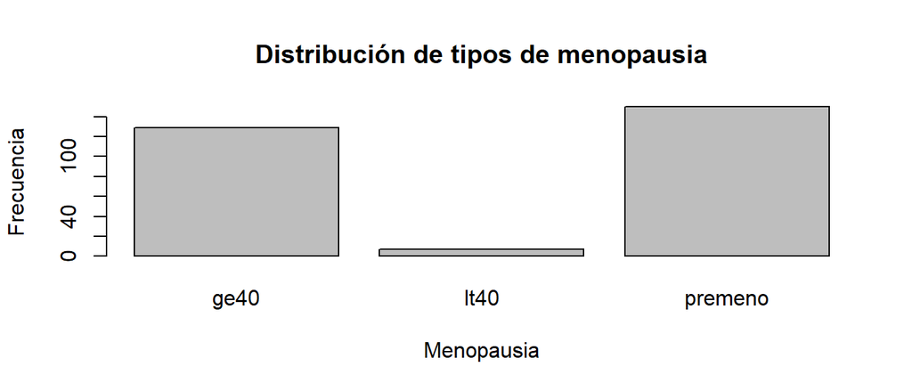

```r
  barplot(table(datos$menopausia),
          xlab="Menopausia",
          ylab="Frecuencia",
          main="Distribución de tipos de menopausia")
```

Este gráfico acompaña a la tabla de frecuencias para una visualización rápida de la distribución de la variable.

[^1]: egutierreza@pucp.edu.pe